# Аналитика отключений систем ЖКХ во Владивостоке

Для того, чтобы проанализировать датасет, импортируем необходимые библиотеки: sqlite3 для работы с базой данных, pandas для манипуляций с данными, matplotlib и seaborn для построения графиков на основе данных.

```python
import sqlite3
import pandas as pd
import matplotlib.pyplot as plt
import seaborn as sea
%matplotlib inline
```

## Базовый уровень — Работа с данными

Подключим базу данных с помощью sqlite3 и получим список её таблиц.

```python
con = sqlite3.connect("D:\Кейс_Аналитика.db")
tableList = pd.read_sql_query("SELECT name FROM sqlite_master WHERE type='table'", con)['name'].to_list()
tableList
```

```
['cities',
 'districts',
 'folk_districts',
 'big_folk_districts',
 'streets',
 'buildings',
 'blackouts',
 'blackouts_buildings']
```

Загрузим для дальнейшей работы три самых крупных таблицы с данными и подгрузим в таблицу 'buildings' остальные данные. Обратим внимание, что загруженные в 'buildings' данные могут нуждаться в очистке, так как в исходных таблицах могут быть дубликаты.

```python
buildingsDf = pd.read_sql(f"SELECT * FROM {tableList[5]}", con)
blackoutsDf = pd.read_sql(f"SELECT * FROM {tableList[6]}", con)
blackouts_buildingsDf = pd.read_sql(f"SELECT * FROM {tableList[7]}", con)
columnIds = ['city_id', 'district_id', 'folk_district_id', 'big_folk_district_id', 'street_id']
columnNames = ['city_name', 'district_name', 'folk_district_name', 'big_folk_district_name', 'street_name']
for i in range(0, 5):
    df = pd.read_sql(f"SELECT * FROM {tableList[i]}", con).rename(columns={'id': columnIds[i], 'name': columnNames[i]})
    buildingsDf = buildingsDf.merge(df, how='left', on=columnIds[i]).drop(columnIds[i], axis=1)
buildingsDf = buildingsDf.drop('city_id', axis=1)
```

Прежде чем готовить самые крупные таблицы, очистим остальные. Загрузим их в dataframe-ы и посмотрим информацию о них. Для удобства будем хранить таблицы в списке, а после окончания работы над ними вынесем их в отдельные переменные.

```python
tableNames = [0, 0, 0, 0, 0]
for i in range(0, 5):
    tableNames[i] = pd.read_sql(f"SELECT * FROM {tableList[i]}", con)
    display(tableNames[i].info())
```

```
<class 'pandas.core.frame.DataFrame'>
RangeIndex: 2 entries, 0 to 1
Data columns (total 2 columns):
 #   Column  Non-Null Count  Dtype
---  ------  --------------  -----
 0   id      2 non-null      object
 1   name    2 non-null      object
dtypes: object(2)
memory usage: 164.0+ bytes
```

```
None
```

```
<class 'pandas.core.frame.DataFrame'>
RangeIndex: 5 entries, 0 to 4
Data columns (total 2 columns):
 #   Column  Non-Null Count  Dtype
---  ------  --------------  -----
 0   id      5 non-null      object
 1   name    5 non-null      object
dtypes: object(2)
memory usage: 212.0+ bytes
```

```
None
```

```
<class 'pandas.core.frame.DataFrame'>
RangeIndex: 3594 entries, 0 to 3593
Data columns (total 2 columns):
 #   Column  Non-Null Count  Dtype
---  ------  --------------  -----
 0   id      3594 non-null   object
 1   name    3594 non-null   object
dtypes: object(2)
memory usage: 56.3+ KB
```

```
None
```

```
<class 'pandas.core.frame.DataFrame'>
RangeIndex: 45 entries, 0 to 44
Data columns (total 2 columns):
 #   Column  Non-Null Count  Dtype
---  ------  --------------  -----
 0   id      45 non-null     object
 1   name    45 non-null     object
dtypes: object(2)
memory usage: 852.0+ bytes
```

```
None
```

```
<class 'pandas.core.frame.DataFrame'>
RangeIndex: 2023 entries, 0 to 2022
Data columns (total 3 columns):
 #   Column   Non-Null Count  Dtype
---  ------   --------------  -----
 0   id       2023 non-null   object
 1   name     2023 non-null   object
 2   city_id  2023 non-null   object
dtypes: object(3)
memory usage: 47.5+ KB
```

```
None
```

Видим, что во всех полях тип данных - object, приведем его к string. Вместе с этим проверим таблицы (кроме streets) на дубликаты - исключим из проверки столбец id и удалим совпадающие строки. Для streets выполним проверку отдельно, так как там есть еще один столбец.

```python
for i in range(0, 5):
    tableNames[i] = tableNames[i].convert_dtypes()
for i in range(0, 4):
    display(f'Количество дубликатов в таблице {i + 1}: {tableNames[i].duplicated(subset=['name']).sum()}')
    tableNames[i] = tableNames[i].drop_duplicates(subset=['name'])
display(f'Количество дубликатов в таблице 5: {tableNames[4].duplicated(subset=['name', 'city_id']).sum()}')
tableNames[4] = tableNames[4].drop_duplicates(subset=['name', 'city_id'])
```

```
'Количество дубликатов в таблице 1: 0'
```

```
'Количество дубликатов в таблице 2: 0'
```

```
'Количество дубликатов в таблице 3: 3526'
```

```
'Количество дубликатов в таблице 4: 0'
```

```
'Количество дубликатов в таблице 5: 0'
```

После удаления дубликатов, проверим уникальные значения полей name на правильность заполнения данных.

```python
for i in range(0, 5):
    display(tableNames[i]['name'].unique())
```

```
<StringArray>
['Артем', 'Владивосток']
Length: 2, dtype: string
```

```
<StringArray>
[     'Ленинский район',   'Первомайский район', 'Первореченский район',
      'Советский район',    'Фрунзенский район']
Length: 5, dtype: string
```

```
<StringArray>
[                          'Центр',                             'БАМ',
            'Гризодубова-Сафонова',                         'Щитовая',
        'Трасса Де-Фриз - Седанка',                       'Фуникулер',
                        'Трудовое',                       'Эгершельд',
                        'Садгород',                    'Первая речка',
                    'Некрасовская',                         'Весеняя',
                         'Спутник',                'Проспект Красоты',
                          'Чуркин',                       'Борисенко',
                         'Змеинка',               'Поворот на Шамору',
                           'Тихая',            'Парк Минного городка',
                       '3 рабочая',                    'Котельникова',
                '64 71 микрорайон',                         'Седанка',
                            'Заря',                   'Академгородок',
         'Енисейская (Автовокзал)',                        'Гайдамак',
                           'Улисс',                         'Патрокл',
                      'О. Русский',                        'Окатовая',
                     'Светланская',                        'Столетие',
                      'Санаторная',                         'Луговая',
                     'Днепровская',                        'Снеговая',
                            'Маяк',                          'Шамора',
                         'Фадеева', 'Вторая речка (Русская-Давыдова)',
                 'Плодово-ягодная',                       'Океанская',
                      'Выселковая',                          'Гоголя',
       'Варяг (Кольцо Багратиона)',                            'Емар',
                       'О. Попова',                         'Баляева',
                    '50 лет ВЛКСМ',                'Красного Знамени',
                  'ТЭЦ(Золоотвал)',                   'Военное шоссе',
                   'Снеговая падь',                       'Горностай',
     'Район горы Оролинный коготь',                    'Лесопитомник',
                'По-ов. Песчанный',                  'П-ов. Песчаный',
                      'о. Русский',                       'о. Попова',
                   'п-ов Песчаный',               '64, 71 микрорайон',
                         'Тавайза',                      'о. Рейнеке',
                         'Угловое',      'Район Хребта Богатая Грива']
Length: 68, dtype: string
```

```
<StringArray>
[             'Центр',                'БАМ',              'Тихая',
             'Шамора',           'Пригород',           'Трудовое',
          'Эгершельд',           'Садгород',       'Первая речка',
            'Весеняя',             'Чуркин',          'Океанская',
            'Луговая',          '3 рабочая',   '64 71 микрорайон',
            'Седанка',               'Заря',       'Вторая Речка',
         'О. Русский',           'Столетие',         'Санаторная',
           'Снеговая',    'Плодово-ягодная',          'О. Попова',
            'Баляева',           'Гайдамак',   'Толстого (Буссе)',
           'Весенняя',          'Борисенко',            'Патрокл',
            'Фадеева',      'Сахарный ключ',            'Спутник',
       'Вторая речка',      'Снеговая падь',              'Чайка',
          'Горностай',          'о. Попова', '64, 71 микрорайоны',
       'Некрасовская',         'о. Русский',     'Третья рабочая',
           'Трудовая',   'По-ов. Песчанный',            'Змеинка']
Length: 45, dtype: string
```

```
<StringArray>
[          '1-й Байкальский пер.',            '1-й Вокзальный пер.',
            '1-й Воровского пер.',           '1-й Зареченский пер.',
              '1-й Линейный пер.',               '1-й Севский пер.',
       '1-й Севский перуулок ул.',             '1-й Уральский пер.',
            '1-й Шахтерский пер.',              '1-я Деповская ул.',
 ...
                   'Янтарная ул.', 'Ярославская (с. Суражевка) ул.',
                'Ярославская ул.',                  'Ярошенко пер.',
                   'Ясеневая ул.', 'Ясеневый (пос. Заводской) пер.',
                  'Ясеневый пер.',                      'Ясная ул.',
                     'Ясный пер.',                    'Яхтовая ул.']
Length: 1839, dtype: string
```

В таблицах cities и districts все хорошо, а в таблицах с народными районами сразу исправим видимые несоответствия. Таблицу с улицами придется рассматривать подробнее, так как там тоже видны несоответствия, но не все, так как элементов слишком много.

```python
for i in range(2, 4):
    tableNames[i]['name'] = tableNames[i]['name'].str.replace('О.', 'о.')
    tableNames[i]['name'] = tableNames[i]['name'].str.replace('микрорайоны', 'микрорайон')
    tableNames[i]['name'] = tableNames[i]['name'].str.replace('64 71', '64, 71')
    tableNames[i]['name'] = tableNames[i]['name'].str.replace('Песчанный', 'Песчаный')
    tableNames[i]['name'] = tableNames[i]['name'].str.replace('П-ов.', 'п-ов')
    tableNames[i]['name'] = tableNames[i]['name'].str.replace('По-ов.', 'п-ов')
    display(tableNames[i]['name'].unique())
```

```
<StringArray>
[                          'Центр',                             'БАМ',
            'Гризодубова-Сафонова',                         'Щитовая',
        'Трасса Де-Фриз - Седанка',                       'Фуникулер',
                        'Трудовое',                       'Эгершельд',
                        'Садгород',                    'Первая речка',
                    'Некрасовская',                         'Весеняя',
                         'Спутник',                'Проспект Красоты',
                          'Чуркин',                       'Борисенко',
                         'Змеинка',               'Поворот на Шамору',
                           'Тихая',            'Парк Минного городка',
                       '3 рабочая',                    'Котельникова',
               '64, 71 микрорайон',                         'Седанка',
                            'Заря',                   'Академгородок',
         'Енисейская (Автовокзал)',                        'Гайдамак',
                           'Улисс',                         'Патрокл',
                      'о. Русский',                        'Окатовая',
                     'Светланская',                        'Столетие',
                      'Санаторная',                         'Луговая',
                     'Днепровская',                        'Снеговая',
                            'Маяк',                          'Шамора',
                         'Фадеева', 'Вторая речка (Русская-Давыдова)',
                 'Плодово-ягодная',                       'Океанская',
                      'Выселковая',                          'Гоголя',
       'Варяг (Кольцо Багратиона)',                            'Емар',
                       'о. Попова',                         'Баляева',
                    '50 лет ВЛКСМ',                'Красного Знамени',
                  'ТЭЦ(Золоотвал)',                   'Военное шоссе',
                   'Снеговая падь',                       'Горностай',
     'Район горы Оролинный коготь',                    'Лесопитомник',
                   'п-ов Песчаный',                         'Тавайза',
                      'о. Рейнеке',                         'Угловое',
      'Район Хребта Богатая Грива']
Length: 63, dtype: string
```

```
<StringArray>
[            'Центр',               'БАМ',             'Тихая',
            'Шамора',          'Пригород',          'Трудовое',
         'Эгершельд',          'Садгород',      'Первая речка',
           'Весеняя',            'Чуркин',         'Океанская',
           'Луговая',         '3 рабочая', '64, 71 микрорайон',
           'Седанка',              'Заря',      'Вторая Речка',
        'о. Русский',          'Столетие',        'Санаторная',
          'Снеговая',   'Плодово-ягодная',         'о. Попова',
           'Баляева',          'Гайдамак',  'Толстого (Буссе)',
          'Весенняя',         'Борисенко',           'Патрокл',
           'Фадеева',     'Сахарный ключ',           'Спутник',
      'Вторая речка',     'Снеговая падь',             'Чайка',
         'Горностай',      'Некрасовская',    'Третья рабочая',
          'Трудовая',     'п-ов Песчаный',           'Змеинка']
Length: 42, dtype: string
```

В этих таблицах проблемных данных больше нет, удаляем появившиеся дубликаты в них и вынесем таблицы в отдельные переменные для удобства анализа после очистки.

```python
for i in range(2, 4):
    display(f'Количество дубликатов в таблице {i + 1}: {tableNames[i].duplicated(subset=['name']).sum()}')
    tableNames[i] = tableNames[i].drop_duplicates(subset=['name'])
citiesDf = tableNames[0]
districtsDf = tableNames[1]
folk_districtsDf = tableNames[2]
big_folk_districtsDf = tableNames[3]
streetsDf = tableNames[4]
```

```
'Количество дубликатов в таблице 3: 5'
```

```
'Количество дубликатов в таблице 4: 3'
```

Исследуем таблицу streets и напишем функцию исправления некоторых неверных полей. Все исправления учесть не получится, так как у меня не получилось выделить общую структуру полей, чтобы привести данные к нормальной форме. Опытным путем было выяснено, что сокращение 'у.' обозначает урочище, 'пр-д' обозначает проезд, 'туп.' обозначает тупик. Я постарался внести в функцию очистки все, что я нашел ручным поиском. Пояснения в скобках я решил скорее оставить, хоть это и дублирует названия улиц, это все-таки дополнительные данные. Так как очистка названий улиц не особо увенчалась успехом, в дальнейшем анализе будем стараться не опираться на нее, а если придется - искать углубленные методы очистки данных.

```python
def cleanStreets (streets):
    streets = streets.str.replace('c', 'с') # слева английская с, справа русская с
    streets = streets.str.replace('ё', 'е')
    streets = streets.str.replace('у.', 'урочище')
    streets = streets.str.replace('пр-д', 'проезд')
    streets = streets.str.replace('туп.', 'тупик')
    streets = streets.str.replace('перуулок ул.', 'пер.')
    streets = streets.str.replace('борисова', 'Борисова')
    streets = streets.str.replace('кневичи', 'Кневичи')
    streets = streets.str.replace('километр', 'км')
    streets = streets.str.replace('-й', '')
    streets = streets.str.replace('трудовое', 'Трудовое')
    streets = streets.str.replace('C/т', 'снт')
    streets = streets.str.replace('с/т', 'снт')
    streets = streets.str.replace('садовое товарищество', 'снт')
    streets = streets.str.replace('днт', 'снт')
    streets = streets.str.replace('дачное неком-ое товарищество', 'снт')
    streets = streets.str.replace('обручева', 'Обручева')
    streets = streets.str.replace('проспект', 'пр-кт')
    return streets

streetsDf['name'] = cleanStreets(streetsDf['name'])
streetsDf = streetsDf.drop_duplicates(subset=['name'])
```

Проверим наличие повторяющихся строк в таблице 'blackouts_buildings'.

```python
display(f"Количество дубликатов в таблице 'blackouts_buildings': {blackouts_buildingsDf.duplicated().sum()}")
```

```
"Количество дубликатов в таблице 'blackouts_buildings': 1215160"
```

Мы видим, что в таблице 'blackouts_buildingsDf' много дубликатов, поэтому продолжим ее исследование.

|  | blackout_id | building_id |
| --- | --- | --- |
| count | 175590 | 1419556 |
| unique | 23517 | 29217 |
| top | 07d47d2befbc62d1f4816cec74ef8b3c | 70da8e1a2fcc360bbd4a39439e4fc487 |
| freq | 2735 | 950 |

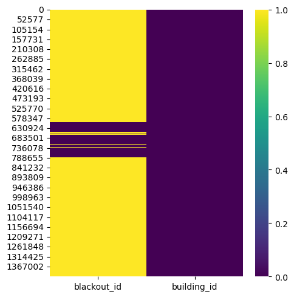

```python
display(blackouts_buildingsDf.describe(include='all'))
plt.figure(figsize=(5, 5))
sea.heatmap(blackouts_buildingsDf.isnull(), cmap='viridis')
plt.tight_layout()
plt.show()
```

В описании таблицы видно, что id отключений записано только в 175590 строках из 1419556, поэтому можно предположить, что либо эта информация не заполнялась, либо отключения в строениях невозможно было отнести к какому либо официальному отключению. В обоих случаях никакой дополнительной информации это не несет. Во второй колонке уникальных значений всего 29217 - это можно объяснить тем, что в одном строении было много отключений, а так как id отключений не были заполнены, отсюда и взялось такое количество дубликатов. Из данных в этой таблице можно выделить только информацию о количестве отключений на строение и количестве строений на отключение, занесем эту информацию в таблицы с отключениями и со строениями.

```python
df = blackouts_buildingsDf.groupby('blackout_id').agg(count=('blackout_id', 'count')).reset_index()
blackoutsDf = blackoutsDf.merge(df, how='left', left_on='id', right_on='blackout_id').drop('blackout_id', axis=1)
blackoutsDf = blackoutsDf.rename(columns={'count': 'building_count'})
blackoutsDf['building_count'] = blackoutsDf['building_count'].fillna(0).astype(int)

df = blackouts_buildingsDf.groupby('building_id').agg(count=('building_id', 'count')).reset_index()
buildingsDf = buildingsDf.merge(df, how='left', left_on='id', right_on='building_id').drop('building_id', axis=1)
buildingsDf = buildingsDf.rename(columns={'count': 'blackout_count'})
buildingsDf['blackout_count'] = buildingsDf['blackout_count'].fillna(0).astype(int)
```

Теперь, когда все поля в двух оставшихся таблицах уникальны, посмотрим на данные в них. Посмотрим на первые 5 строк таблицы 'buildings' и информацию о ней, чтобы определить правильность типов данных в столбцах.

```python
display(buildingsDf.head())
display(buildingsDf.info())
```

|  | id | number | is_fake | type | coordinates | city_name | district_name | folk_district_name | big_folk_district_name | street_name | blackout_count |
| --- | --- | --- | --- | --- | --- | --- | --- | --- | --- | --- | --- |
| 0 | b428b92bb123994a56234bb6eeeed414 | 1 | 0 | нежилое | [{"lat": 43.14199293270051, "lon": 131.9080723... | Владивосток | Первореченский район | Днепровская | Столетие | 100-летия Владивостока пр-кт | 55 |
| 1 | 24aa25303f0f91ede8ee0c0d324c8ee3 | 100 | 0 | жилое многоквартирное | [{"lat": 43.171246518452826, "lon": 131.917043... | Владивосток | Советский район | Вторая речка (Русская-Давыдова) | Вторая речка | 100-летия Владивостока пр-кт | 164 |
| 2 | 504f6b8bd5daeba64beb62bda8b3c12a | 100А | 0 | жилое многоквартирное | [{"lat": 43.17160112621735, "lon": 131.9178653... | Владивосток | Советский район | Вторая речка (Русская-Давыдова) | Вторая речка | 100-летия Владивостока пр-кт | 303 |
| 3 | 87d459096286c57ed5e780205f041e68 | 100В | 0 | жилое многоквартирное | [{"lat": 43.17208966911542, "lon": 131.9183524... | Владивосток | Советский район | Вторая речка (Русская-Давыдова) | Вторая речка | 100-летия Владивостока пр-кт | 174 |
| 4 | a4f6e19b37548845b4ee10c573809e68 | 102 | 0 | жилое многоквартирное | [{"lat": 43.172186535721075, "lon": 131.917439... | Владивосток | Советский район | Вторая речка (Русская-Давыдова) | Вторая речка | 100-летия Владивостока пр-кт | 304 |

```
<class 'pandas.core.frame.DataFrame'>
RangeIndex: 58199 entries, 0 to 58198
Data columns (total 11 columns):
 #   Column                  Non-Null Count  Dtype
---  ------                  --------------  -----
 0   id                      58199 non-null  object
 1   number                  58199 non-null  object
 2   is_fake                 58199 non-null  int64
 3   type                    34631 non-null  object
 4   coordinates             50521 non-null  object
 5   city_name               58199 non-null  object
 6   district_name           34606 non-null  object
 7   folk_district_name      26009 non-null  object
 8   big_folk_district_name  33063 non-null  object
 9   street_name             58199 non-null  object
 10  blackout_count          58199 non-null  int32
dtypes: int32(1), int64(1), object(9)
memory usage: 4.7+ MB
```

```
None
```

Все типы object можно перевести в string для удобства дальнейшего анализа. Посмотрим уникальные значения полей, которые можно перевести в более подходящий тип данных.

```python
buildingsDf = buildingsDf.convert_dtypes()
display(buildingsDf['number'].unique())
display(buildingsDf['is_fake'].unique())
display(buildingsDf['coordinates'].unique())
```

```
<StringArray>
[        '1',       '100',      '100А',      '100В',       '102',       '103',
      '103А',      '103Б',       '104',       '105',
 ...
  '24 кор.1', '275 кор.3',      '721Е', '23 стр.16',   '5 кор.4', '5 кор.1/1',
 '5 кор.1/2', '5 кор.1/3',  '34 кор.2',     '111/1']
Length: 5576, dtype: string
```

```
<IntegerArray>
[0, 1]
Length: 2, dtype: Int64
```

```
<StringArray>
[ '[{"lat": 43.14199293270051, "lon": 131.90807239774105}]',
 '[{"lat": 43.171246518452826, "lon": 131.91704320382007}]',
  '[{"lat": 43.17160112621735, "lon": 131.91786531590515}]',
  '[{"lat": 43.17208966911542, "lon": 131.91835241829773}]',
 '[{"lat": 43.172186535721075, "lon": 131.91743981447928}]',
 '[{"lat": 43.162369350000006, "lon": 131.91161372933547}]',
                                                       <NA>,
   '[{"lat": 43.16054901980439, "lon": 131.9113894477184}]',
  '[{"lat": 43.17288578534359, "lon": 131.91793459287737}]',
   '[{"lat": 43.16534315513648, "lon": 131.9102843378032}]',
 ...
  '[{"lat": 43.16361822282004, "lon": 131.92853005736777}]',
  '[{"lat": 43.13914764063666, "lon": 131.93515693051634}]',
 '[{"lat": 43.172278600000006, "lon": 132.07662820000002}]',
  '[{"lat": 43.21043186401401, "lon": 132.01662199618352}]',
  '[{"lat": 43.15504106551957, "lon": 131.91632159798016}]',
   '[{"lat": 43.3175557006135, "lon": 132.10946000797847}]',
 '[{"lat": 43.238808356817536, "lon": 132.02954372253205}]',
   '[{"lat": 43.0676023780005, "lon": 131.93077770519156}]',
        '[{"lat": 43.102418400000005, "lon": 131.8974057}]',
   '[{"lat": 43.08615334945546, "lon": 131.9512444827541}]']
Length: 47977, dtype: string
```

Со столбцом number ничего не сделать, так как там в некоторых полях есть приписки "кор." или "стр.", так что оставим его строкой. В столбце is_fake, как и предполагалось по названию столбца, всего два значения - 1 и 0, значит его можно перевести в тип bool. Столбец coordinates с помощью регулярных выражений разобьем на два float столбца - latitude и longitude. При переводе во float часть знаков после запятой отрежется, но для данных это не критично, так как для широты и долготы достаточно точности в 5 знаков после запятой для точного отображения местоположения строения. Это можно проверить на любой онлайн карте: вставить туда полные координаты и постепенно убирать знаки после запятой.

```python
buildingsDf['is_fake'] = buildingsDf['is_fake'].astype(bool)
buildingsDf[['latitude', 'longitude']] = buildingsDf['coordinates'].str.extract(
    r'"lat":\s*(?P<latitude>\d+\.\d+).*?"lon":\s*(?P<longitude>\d+\.\d+)').astype(float)
buildingsDf = buildingsDf.convert_dtypes()
display(buildingsDf.describe(include='all'))
```

|  | id | number | is_fake | type | coordinates | city_name | district_name | folk_district_name | big_folk_district_name | street_name | blackout_count | latitude | longitude |
| --- | --- | --- | --- | --- | --- | --- | --- | --- | --- | --- | --- | --- | --- |
| count | 58199 | 58199 | 58199 | 34631 | 50521 | 58199 | 34606 | 26009 | 33063 | 58199 | 58199.0 | 50495.0 | 50495.0 |
| unique | 58199 | 5576 | 2 | 29 | 47976 | 2 | 5 | 67 | 44 | 1839 | <NA> | <NA> | <NA> |
| top | b428b92bb123994a56234bb6eeeed414 | 5 | False | частный дом | [] | Владивосток | Советский район | Трудовое | Трудовое | снт Кирпичики (у. Соловей-Ключ) ул. | <NA> | <NA> | <NA> |
| freq | 1 | 1035 | 46119 | 19941 | 26 | 36140 | 19410 | 2676 | 3695 | 638 | <NA> | <NA> | <NA> |
| mean | NaN | NaN | NaN | NaN | NaN | NaN | NaN | NaN | NaN | NaN | 24.391416 | 43.265019 | 132.058211 |
| std | NaN | NaN | NaN | NaN | NaN | NaN | NaN | NaN | NaN | NaN | 67.768322 | 0.113366 | 0.120062 |
| min | NaN | NaN | NaN | NaN | NaN | NaN | NaN | NaN | NaN | NaN | 0.0 | 42.916183 | 131.713021 |
| 25% | NaN | NaN | NaN | NaN | NaN | NaN | NaN | NaN | NaN | NaN | 0.0 | 43.161242 | 131.942961 |
| 50% | NaN | NaN | NaN | NaN | NaN | NaN | NaN | NaN | NaN | NaN | 1.0 | 43.281206 | 132.071102 |
| 75% | NaN | NaN | NaN | NaN | NaN | NaN | NaN | NaN | NaN | NaN | 20.0 | 43.356985 | 132.153647 |
| max | NaN | NaN | NaN | NaN | NaN | NaN | NaN | NaN | NaN | NaN | 950.0 | 43.482719 | 132.334494 |

В результате заполнилось 50495 различных координат, а в исходном столбце было 50521. При этом, если посмотреть внимательнее на столбец coordinates, самое частое значение в столбце - это [] и повторялось оно 26 раз, а 50521-50495=26. Получается, заполнились все координаты, кроме пустых, а значит данных мы не потеряли, можно удалять столбец coordinates.

```python
buildingsDf = buildingsDf.drop('coordinates', axis=1)
display(buildingsDf.head())
display(buildingsDf.info())
```

|  | id | number | is_fake | type | city_name | district_name | folk_district_name | big_folk_district_name | street_name | blackout_count | latitude | longitude |
| --- | --- | --- | --- | --- | --- | --- | --- | --- | --- | --- | --- | --- |
| 0 | b428b92bb123994a56234bb6eeeed414 | 1 | False | нежилое | Владивосток | Первореченский район | Днепровская | Столетие | 100-летия Владивостока пр-кт | 55 | 43.141993 | 131.908072 |
| 1 | 24aa25303f0f91ede8ee0c0d324c8ee3 | 100 | False | жилое многоквартирное | Владивосток | Советский район | Вторая речка (Русская-Давыдова) | Вторая речка | 100-летия Владивостока пр-кт | 164 | 43.171247 | 131.917043 |
| 2 | 504f6b8bd5daeba64beb62bda8b3c12a | 100А | False | жилое многоквартирное | Владивосток | Советский район | Вторая речка (Русская-Давыдова) | Вторая речка | 100-летия Владивостока пр-кт | 303 | 43.171601 | 131.917865 |
| 3 | 87d459096286c57ed5e780205f041e68 | 100В | False | жилое многоквартирное | Владивосток | Советский район | Вторая речка (Русская-Давыдова) | Вторая речка | 100-летия Владивостока пр-кт | 174 | 43.17209 | 131.918352 |
| 4 | a4f6e19b37548845b4ee10c573809e68 | 102 | False | жилое многоквартирное | Владивосток | Советский район | Вторая речка (Русская-Давыдова) | Вторая речка | 100-летия Владивостока пр-кт | 304 | 43.172187 | 131.91744 |

```
<class 'pandas.core.frame.DataFrame'>
RangeIndex: 58199 entries, 0 to 58198
Data columns (total 12 columns):
 #   Column                  Non-Null Count  Dtype
---  ------                  --------------  -----
 0   id                      58199 non-null  string
 1   number                  58199 non-null  string
 2   is_fake                 58199 non-null  boolean
 3   type                    34631 non-null  string
 4   city_name               58199 non-null  string
 5   district_name           34606 non-null  string
 6   folk_district_name      26009 non-null  string
 7   big_folk_district_name  33063 non-null  string
 8   street_name             58199 non-null  string
 9   blackout_count          58199 non-null  Int32
 10  latitude                50495 non-null  Float64
 11  longitude               50495 non-null  Float64
dtypes: Float64(2), Int32(1), boolean(1), string(8)
memory usage: 4.9 MB
```

```
None
```

Теперь все столбцы таблицы 'buildings' приведены к подходящим типам данных. Далее посмотрим на первые 5 строк таблицы 'blackouts' и информацию о ней, чтобы определить правильность типов данных в столбцах.

```python
display(blackoutsDf.head())
display(blackoutsDf.info())
```

|  | id | start_date | end_date | description | type | initiator_name | source | building_count |
| --- | --- | --- | --- | --- | --- | --- | --- | --- |
| 0 | f88cefa506f44ebf8f010b8681b5449e | 2018-01-01 00:08:00 | 2018-01-01 09:00:00 | Авария на сети электроснабжения, ведутся восст... | electricity | МУПВ ВПЭС (электрические сети Ленинского района) | Единая дежурная диспетчерская служба города (Л... | 98 |
| 1 | 38ddf6852801fa90cc70f9770239961e | 2018-01-01 00:24:00 | 2018-01-01 10:00:00 | Авария на электролинии, остановка работы насос... | cold_water | МУПВ ВПЭС (электрические сети Ленинского района) | Единая дежурная диспетчерская служба города (Л... | 56 |
| 2 | 53c570099fe380dce9e56e2ace9cfa9c | 2018-01-01 10:44:00 | 2018-01-02 18:00:00 | Авария в системе водоснабжения дома. Жителям н... | hot_water | ООО "Управляющая компания "Регион-ЖКХ" | Аварийная служба ООО "Мадикс" | 1 |
| 3 | 9c1b9ebbd9a698eef046b27cb3568745 | 2018-01-01 11:32:00 | 2018-01-01 15:00:00 | Авария на сети электроснабжения, ведутся восст... | electricity | МУПВ ВПЭС (электрические сети Фрунзенского рай... | Единая дежурная диспетчерская служба города (Ф... | 27 |
| 4 | 8aa631cb343aac0731bbde806dfa6d8c | 2018-01-01 11:33:00 | 2018-01-01 15:00:00 | Авария на электролинии, остановка работы насос... | hot_water | МУПВ ВПЭС (электрические сети Фрунзенского рай... | Единая дежурная диспетчерская служба города (Ф... | 4 |

```
<class 'pandas.core.frame.DataFrame'>
RangeIndex: 25264 entries, 0 to 25263
Data columns (total 8 columns):
 #   Column          Non-Null Count  Dtype
---  ------          --------------  -----
 0   id              25264 non-null  object
 1   start_date      25264 non-null  object
 2   end_date        25264 non-null  object
 3   description     25264 non-null  object
 4   type            25264 non-null  object
 5   initiator_name  25264 non-null  object
 6   source          8722 non-null   object
 7   building_count  25264 non-null  int32
dtypes: int32(1), object(7)
memory usage: 1.4+ MB
```

```
None
```

Повторим те же действия, что и для таблицы 'buildings' и выведем уникальные значения столбцов с датами.

```python
blackoutsDf = blackoutsDf.convert_dtypes()
display(blackoutsDf['start_date'].unique())
display(blackoutsDf['end_date'].unique())
```

```
<StringArray>
['2018-01-01 00:08:00', '2018-01-01 00:24:00', '2018-01-01 10:44:00',
 '2018-01-01 11:32:00', '2018-01-01 11:33:00', '2018-01-01 11:50:00',
 '2018-01-01 13:02:00', '2018-01-01 14:31:00', '2018-01-01 16:10:00',
 '2018-01-01 16:11:00',
 ...
 '2019-12-30 19:01:00', '2019-12-30 20:13:00', '2019-12-30 21:03:00',
 '2019-12-30 21:12:00', '2019-12-30 22:35:00', '2019-12-31 06:47:00',
 '2019-12-31 10:54:00', '2019-12-31 15:01:00', '2019-12-31 17:09:00',
 '2019-12-31 20:29:00']
Length: 19739, dtype: string
```

```
<StringArray>
['2018-01-01 09:00:00', '2018-01-01 10:00:00', '2018-01-02 18:00:00',
 '2018-01-01 15:00:00', '2018-01-01 16:00:00', '2018-01-02 12:00:00',
 '2018-01-05 12:00:00', '2018-01-03 18:00:00', '2018-01-01 22:00:00',
 '2018-01-01 19:00:00',
 ...
 '2019-12-31 12:00:00', '2019-12-30 18:00:00', '2019-12-30 16:00:00',
 '2019-12-30 15:00:00', '2019-12-30 19:00:00', '2020-01-04 12:00:00',
 '2019-12-30 20:00:00', '2019-12-31 15:00:00', '2019-12-31 21:00:00',
 '2019-12-31 20:51:00']
Length: 7941, dtype: string
```

Даты занесены в столбцы в формате год-месяц-день час:минута:секунда, их можно преобразовать в тип datetime.

```python
blackoutsDf['start_date'] = pd.to_datetime(blackoutsDf['start_date'])
blackoutsDf['end_date'] = pd.to_datetime(blackoutsDf['end_date'])
display(blackoutsDf.head())
display(blackoutsDf.info())
```

|  | id | start_date | end_date | description | type | initiator_name | source | building_count |
| --- | --- | --- | --- | --- | --- | --- | --- | --- |
| 0 | f88cefa506f44ebf8f010b8681b5449e | 2018-01-01 00:08:00 | 2018-01-01 09:00:00 | Авария на сети электроснабжения, ведутся восст... | electricity | МУПВ ВПЭС (электрические сети Ленинского района) | Единая дежурная диспетчерская служба города (Л... | 98 |
| 1 | 38ddf6852801fa90cc70f9770239961e | 2018-01-01 00:24:00 | 2018-01-01 10:00:00 | Авария на электролинии, остановка работы насос... | cold_water | МУПВ ВПЭС (электрические сети Ленинского района) | Единая дежурная диспетчерская служба города (Л... | 56 |
| 2 | 53c570099fe380dce9e56e2ace9cfa9c | 2018-01-01 10:44:00 | 2018-01-02 18:00:00 | Авария в системе водоснабжения дома. Жителям н... | hot_water | ООО "Управляющая компания "Регион-ЖКХ" | Аварийная служба ООО "Мадикс" | 1 |
| 3 | 9c1b9ebbd9a698eef046b27cb3568745 | 2018-01-01 11:32:00 | 2018-01-01 15:00:00 | Авария на сети электроснабжения, ведутся восст... | electricity | МУПВ ВПЭС (электрические сети Фрунзенского рай... | Единая дежурная диспетчерская служба города (Ф... | 27 |
| 4 | 8aa631cb343aac0731bbde806dfa6d8c | 2018-01-01 11:33:00 | 2018-01-01 15:00:00 | Авария на электролинии, остановка работы насос... | hot_water | МУПВ ВПЭС (электрические сети Фрунзенского рай... | Единая дежурная диспетчерская служба города (Ф... | 4 |

```
<class 'pandas.core.frame.DataFrame'>
RangeIndex: 25264 entries, 0 to 25263
Data columns (total 8 columns):
 #   Column          Non-Null Count  Dtype
---  ------          --------------  -----
 0   id              25264 non-null  string
 1   start_date      25264 non-null  datetime64[ns]
 2   end_date        25264 non-null  datetime64[ns]
 3   description     25264 non-null  string
 4   type            25264 non-null  string
 5   initiator_name  25264 non-null  string
 6   source          8722 non-null   string
 7   building_count  25264 non-null  Int32
dtypes: Int32(1), datetime64[ns](2), string(5)
memory usage: 1.5 MB
```

```
None
```

Все столбцы 'blackouts' приведены к подходящим типам данных. Теперь вернемся к поиску дубликатов. Исключим из проверки столбец id, так как одинаковые отключения могли внести несколько раз под разными идентификаторами. Проверим, принимались ли одни и те же отключения из разных источников, исключив столбец source. Дубликатов этого типа одинаковое количество - по 12 штук, значит это одинаковые множества, удаляем повторяющиеся отключения из разных источников. После этого исключим из проверки столбец building_count, так как среди строений тоже могут быть дубликаты. Таких нашлось 67, но, вместо удаления, просуммируем дубликаты по столбцу building_count, чтобы не потерять данные.

При этом стоит учитывать, что надежность данных в столбце building_count при этом снижается, так как, как уже упоминалось, среди строений могут быть дубликаты, поэтому при будущем анализе нужно будет с осторожностью относиться к этому столбцу. После группировки в таблице столбцы перемешались, поэтому восстанавливаем первоначальный порядок столбцов. Я думаю, что остальные данные ('start_date', 'end_date', 'description', 'type', 'initiator_name) однозначно определяют одно отключение, поэтому дальнейшее исследование на дубликаты не требуется. Уточню, что под однозначным определением я подразумеваю, что при изменении одного из однозначно определяющих полей отключения это будет уже другое отключение.

```python
display(blackoutsDf.duplicated(subset=['start_date', 'end_date', 'description', 'type', 'initiator_name', 'source', 'building_count']).sum())
display(blackoutsDf.duplicated(subset=['start_date', 'end_date', 'description', 'type', 'initiator_name', 'building_count']).sum())
blackoutsDf = blackoutsDf.drop_duplicates(subset=['start_date', 'end_date', 'description', 'type', 'initiator_name', 'building_count'])
display(blackoutsDf.duplicated(subset=['start_date', 'end_date', 'description', 'type', 'initiator_name']).sum())
blackoutsDf = blackoutsDf.groupby(['start_date', 'end_date', 'description', 'type', 'initiator_name'], as_index=False).sum()
blackoutsDf = blackoutsDf[['id', 'start_date', 'end_date', 'description', 'type', 'initiator_name', 'source', 'building_count']]
display(blackoutsDf.info())
```

```
12
```

```
12
```

```
67
```

```
<class 'pandas.core.frame.DataFrame'>
RangeIndex: 25185 entries, 0 to 25184
Data columns (total 8 columns):
 #   Column          Non-Null Count  Dtype
---  ------          --------------  -----
 0   id              25185 non-null  string
 1   start_date      25185 non-null  datetime64[ns]
 2   end_date        25185 non-null  datetime64[ns]
 3   description     25185 non-null  string
 4   type            25185 non-null  string
 5   initiator_name  25185 non-null  string
 6   source          25185 non-null  string
 7   building_count  25185 non-null  Int32
dtypes: Int32(1), datetime64[ns](2), string(5)
memory usage: 1.5 MB
```

```
None
```

После использования groupby().sum() появилось неожиданное поведение - пустые поля колонки source заполнились нулями, исправим это.

```python
blackoutsDf['source'] = blackoutsDf['source'].replace('0', None)
display(blackoutsDf.info())
```

```
<class 'pandas.core.frame.DataFrame'>
RangeIndex: 25185 entries, 0 to 25184
Data columns (total 8 columns):
 #   Column          Non-Null Count  Dtype
---  ------          --------------  -----
 0   id              25185 non-null  string
 1   start_date      25185 non-null  datetime64[ns]
 2   end_date        25185 non-null  datetime64[ns]
 3   description     25185 non-null  string
 4   type            25185 non-null  string
 5   initiator_name  25185 non-null  string
 6   source          8684 non-null   string
 7   building_count  25185 non-null  Int32
dtypes: Int32(1), datetime64[ns](2), string(5)
memory usage: 1.5 MB
```

```
None
```

Теперь поищем дубликаты в таблице 'buildings'. Строение определяется однозначно следующими столбцами: 'number', 'city_name', 'street_name', поэтому сразу проверим количество дубликатов по этим полям, чтобы не перебирать все постепенно.

```python
display(buildingsDf.duplicated(subset=['number', 'city_name', 'street_name']).sum())
```

```
0
```

Дубликатов нет, значит можно далее поработать с самими полями. Сразу рассмотрим уникальные значения столбца type, так как при предыдущей очистке в нем были замечены странные поля.

```python
display(buildingsDf['type'].unique())
```

```
<StringArray>
[                  'нежилое',     'жилое многоквартирное',
              'общественное',                        <NA>,
                'строящееся',               'частный дом',
          'производственное',          'Нежилое строение',
                   'Нежилое',            'Жилое сельское',
   'Жилое сельское строение',            'Жилое строение',
               'разрушенное',                     'Жилое',
                      'дача',                  'строение',
               'Разрушенное',                    'гаражи',
               'планируемое',                'Строящееся',
            'Строение жилое',       'Строящееся строение',
 'Производственное строение',          'Производственное',
                       'СНТ',   'Строение жилое сельское',
          'Строение нежилое',       'Строение строящееся',
 'Строение производственное',      'Постройка без адреса']
Length: 30, dtype: string
```

Видно, что разные значения полей отражают одну и ту же информацию о строениях, поэтому их надо привести к общему виду. Преобразуем все заглавные буквы в столбце в строчные. Далее можно предположить, что ключевое слово 'строение' в типах не значит чего-то особенного, поэтому уберем его, чтобы больше обобщить типы строений. При этом у нас есть тип 'строение', который стоит сохранить, так как, хоть он пока что не несет смысловой нагрузки, мы можем потерять информацию, если уберем его.

```python
buildingsDf['type'] = buildingsDf['type'].str.lower()
buildingsDf['type'] = buildingsDf['type'].replace('строение', 'temp')
buildingsDf['type'] = buildingsDf['type'].str.replace('строение', '').str.strip()
buildingsDf['type'] = buildingsDf['type'].replace('temp', 'строение')
display(buildingsDf['type'].unique())
```

```
<StringArray>
[              'нежилое', 'жилое многоквартирное',          'общественное',
                    <NA>,            'строящееся',           'частный дом',
      'производственное',        'жилое сельское',                 'жилое',
           'разрушенное',                  'дача',              'строение',
                'гаражи',           'планируемое',                   'снт',
  'постройка без адреса']
Length: 16, dtype: string
```

У нас осталось множество разных типов, не повторяющих друг друга. Некоторые типы не очень полезны в контексте работы с отключениями электричества, отопления и воды (например, тип 'разрушенное'), но решение об исключении этих данных будет приниматься уже в процессе анализа данных, так как эта информация также может пригодиться. С очисткой этого столбца мы закончили, еще один столбец, вызывающий вопросы - 'is_fake'. Посмотрим на строения, у которых в этом столбце стоит значение True.

```python
buildingsDf.loc[buildingsDf['is_fake'] == True]
```

|  | id | number | is_fake | type | city_name | district_name | folk_district_name | big_folk_district_name | street_name | blackout_count | latitude | longitude |
| --- | --- | --- | --- | --- | --- | --- | --- | --- | --- | --- | --- | --- |
| 6 | 7c1593f55880ac0bbebf85f763b665ee | 103А | True | <NA> | Владивосток | <NA> | <NA> | <NA> | 100-летия Владивостока пр-кт | 19 | <NA> | <NA> |
| 11 | 8efe443f310b32d6ad6d6974739b06f9 | 105А стр.2 | True | нежилое | Владивосток | Советский район | Енисейская (Автовокзал) | Вторая речка | 100-летия Владивостока пр-кт | 20 | 43.165596 | 131.912023 |
| 13 | 72025bec78133bf2b804cfac5d4e7df6 | 105А стр.8 | True | нежилое | Владивосток | Советский район | Енисейская (Автовокзал) | Вторая речка | 100-летия Владивостока пр-кт | 20 | 43.164843 | 131.912498 |
| 14 | b7cb6104dd1d8aa6c8752b879da04eee | 105А стр.9 | True | нежилое | Владивосток | Советский район | Енисейская (Автовокзал) | Вторая речка | 100-летия Владивостока пр-кт | 19 | 43.164572 | 131.912497 |
| 30 | dfc0711ac3a6c9d346609732247f00bd | 116А | True | строящееся | Владивосток | Советский район | Вторая речка (Русская-Давыдова) | Вторая речка | 100-летия Владивостока пр-кт | 35 | <NA> | <NA> |
| ... | ... | ... | ... | ... | ... | ... | ... | ... | ... | ... | ... | ... |
| 58156 | 2c4c87cef87b01625ed7c82df5fccec7 | 64 | True | <NA> | Владивосток | Советский район | <NA> | Весенняя | Ст юбилейное ул. | 0 | 43.277273 | 132.085955 |
| 58157 | 33faf12a6e3afcea57129088b3b5eb25 | 80 | True | <NA> | Владивосток | Советский район | <NA> | Весенняя | Ст юбилейное ул. | 0 | 43.275535 | 132.085174 |
| 58159 | 278f34014f8dc54413bb6921a2d1ba17 | 59 | True | <NA> | Артем | <NA> | <NA> | <NA> | Гагарина ул. | 0 | 43.323238 | 132.159179 |
| 58161 | 58e3a35a7da870bb5c9e99796df1f1b8 | 43 | True | <NA> | Артем | <NA> | <NA> | <NA> | ст Дубрава ул. | 0 | 43.318908 | 132.1167 |
| 58162 | ae32cef35fc707f4bc1c88a5b2baa15d | 44 | True | <NA> | Артем | <NA> | <NA> | <NA> | ст Муравей ул. | 0 | 43.32154 | 132.107858 |

12080 rows × 12 columns

Координаты 11, 13 и 14 строк показывают на жилой комплекс Старк, внутри которого здания на карте и на спутниковой съемке совсем не совпадают, при поиске жилого комплекса понятно, что он еще строится. Получается, тип строения 'нежилое' также может включать в себя 'строящееся'. При поиске 6 и 30 строки по улице и номеру, ничего не было найдено. При этом 58156 и 58157 строки есть и на карте, и на спутниковой съемке, но на одной из карт 58157 с номером 9 и улицей Танкерная. Однозначных выводов сделать не получается, ручной анализ столбца ничего не дал, в будущем анализе датасета будем относиться к этой информации осторожно.

Далее рассмотрим следующие три столбца: 'folk_district_name', 'big_folk_district_name' и 'street_name'. Применим к ним те же изменения, что и к таблицам, из которых были взяты эти данные.

```python
buildingsDfColumns = ['folk_district_name', 'big_folk_district_name']
for i in range(0, 2):
    buildingsDf[buildingsDfColumns[i]] = buildingsDf[buildingsDfColumns[i]].str.replace('О.', 'о.')
    buildingsDf[buildingsDfColumns[i]] = buildingsDf[buildingsDfColumns[i]].str.replace('микрорайоны', 'микрорайон')
    buildingsDf[buildingsDfColumns[i]] = buildingsDf[buildingsDfColumns[i]].str.replace('64 71', '64, 71')
    buildingsDf[buildingsDfColumns[i]] = buildingsDf[buildingsDfColumns[i]].str.replace('Песчанный', 'Песчаный')
    buildingsDf[buildingsDfColumns[i]] = buildingsDf[buildingsDfColumns[i]].str.replace('П-ов.', 'п-ов')
    buildingsDf[buildingsDfColumns[i]] = buildingsDf[buildingsDfColumns[i]].str.replace('По-ов.', 'п-ов')
buildingsDf['street_name'] = cleanStreets(buildingsDf['street_name'])
```

Взглянем, где в получившихся таблицах buildings и blackouts есть пропуски с помощью графика.

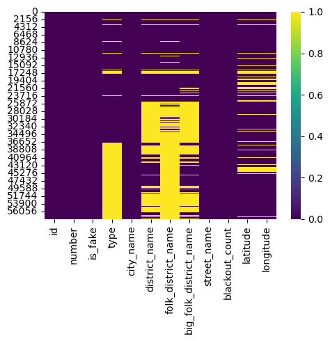

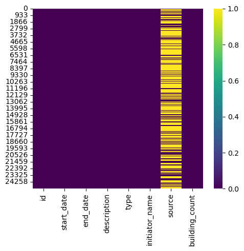

```python
plt.figure(figsize=(5, 5))
sea.heatmap(buildingsDf.isnull(), cmap='viridis')
plt.tight_layout()
plt.show()
plt.figure(figsize=(5, 5))
sea.heatmap(blackoutsDf.isnull(), cmap='viridis')
plt.tight_layout()
plt.show()
```

В таблице blackouts колонку source не получится заполнить, так как доступа к этим данным у нас нет. В таблице buildings: колонку type можно заполнить только вручную, рассматривая каждое строение отдельно, колонки latitude и longitude можно заполнить, посмотрев на карте строение по номеру и названию улицы, колонки 'district_name', 'folk_district_name', 'big_folk_district_name' можно заполнить, четко определив границы всех районов и расставить здания по координатам. Мы заполним эти поля, если они понадобятся в дальнейшем анализе.

В целом мы закончили с подготовкой данных к анализу, посмотрим на получившиеся данные.

```python
display(folk_districtsDf.info())
display(big_folk_districtsDf.info())
display(streetsDf.info())
display(buildingsDf.info())
display(blackoutsDf.info())
```

```
<class 'pandas.core.frame.DataFrame'>
Index: 63 entries, 0 to 1066
Data columns (total 2 columns):
 #   Column  Non-Null Count  Dtype
---  ------  --------------  -----
 0   id      63 non-null     string
 1   name    63 non-null     string
dtypes: string(2)
memory usage: 1.5 KB
```

```
None
```

```
<class 'pandas.core.frame.DataFrame'>
Index: 42 entries, 0 to 44
Data columns (total 2 columns):
 #   Column  Non-Null Count  Dtype
---  ------  --------------  -----
 0   id      42 non-null     string
 1   name    42 non-null     string
dtypes: string(2)
memory usage: 1008.0 bytes
```

```
None
```

```
<class 'pandas.core.frame.DataFrame'>
Index: 1832 entries, 0 to 2022
Data columns (total 3 columns):
 #   Column   Non-Null Count  Dtype
---  ------   --------------  -----
 0   id       1832 non-null   string
 1   name     1832 non-null   string
 2   city_id  1832 non-null   string
dtypes: string(3)
memory usage: 57.2 KB
```

```
None
```

```
<class 'pandas.core.frame.DataFrame'>
RangeIndex: 58199 entries, 0 to 58198
Data columns (total 12 columns):
 #   Column                  Non-Null Count  Dtype
---  ------                  --------------  -----
 0   id                      58199 non-null  string
 1   number                  58199 non-null  string
 2   is_fake                 58199 non-null  boolean
 3   type                    34631 non-null  string
 4   city_name               58199 non-null  string
 5   district_name           34606 non-null  string
 6   folk_district_name      26009 non-null  string
 7   big_folk_district_name  33063 non-null  string
 8   street_name             58199 non-null  string
 9   blackout_count          58199 non-null  Int32
 10  latitude                50495 non-null  Float64
 11  longitude               50495 non-null  Float64
dtypes: Float64(2), Int32(1), boolean(1), string(8)
memory usage: 4.9 MB
```

```
None
```

```
<class 'pandas.core.frame.DataFrame'>
RangeIndex: 25185 entries, 0 to 25184
Data columns (total 8 columns):
 #   Column          Non-Null Count  Dtype
---  ------          --------------  -----
 0   id              25185 non-null  string
 1   start_date      25185 non-null  datetime64[ns]
 2   end_date        25185 non-null  datetime64[ns]
 3   description     25185 non-null  string
 4   type            25185 non-null  string
 5   initiator_name  25185 non-null  string
 6   source          8684 non-null   string
 7   building_count  25185 non-null  Int32
dtypes: Int32(1), datetime64[ns](2), string(5)
memory usage: 1.5 MB
```

```
None
```

## Средний уровень — Анализ данных и визуализация

Начнем с описательной статистики датасета. Так как числовых полей у наc немного, достаточно будет функции .describe().

```python
display(buildingsDf.describe(include='all'))
display(blackoutsDf.describe(include='all'))
```

|  | id | number | is_fake | type | city_name | district_name | folk_district_name | big_folk_district_name | street_name | blackout_count | latitude | longitude |
| --- | --- | --- | --- | --- | --- | --- | --- | --- | --- | --- | --- | --- |
| count | 58199 | 58199 | 58199 | 34631 | 58199 | 34606 | 26009 | 33063 | 58199 | 58199.0 | 50495.0 | 50495.0 |
| unique | 58199 | 5576 | 2 | 15 | 2 | 5 | 63 | 41 | 1832 | <NA> | <NA> | <NA> |
| top | b428b92bb123994a56234bb6eeeed414 | 5 | False | частный дом | Владивосток | Советский район | Трудовое | Трудовое | снт Кирпичики (урочище Соловей-Ключ) ул. | <NA> | <NA> | <NA> |
| freq | 1 | 1035 | 46119 | 19941 | 36140 | 19410 | 2676 | 3695 | 638 | <NA> | <NA> | <NA> |
| mean | NaN | NaN | NaN | NaN | NaN | NaN | NaN | NaN | NaN | 24.391416 | 43.265019 | 132.058211 |
| std | NaN | NaN | NaN | NaN | NaN | NaN | NaN | NaN | NaN | 67.768322 | 0.113366 | 0.120062 |
| min | NaN | NaN | NaN | NaN | NaN | NaN | NaN | NaN | NaN | 0.0 | 42.916183 | 131.713021 |
| 25% | NaN | NaN | NaN | NaN | NaN | NaN | NaN | NaN | NaN | 0.0 | 43.161242 | 131.942961 |
| 50% | NaN | NaN | NaN | NaN | NaN | NaN | NaN | NaN | NaN | 1.0 | 43.281206 | 132.071102 |
| 75% | NaN | NaN | NaN | NaN | NaN | NaN | NaN | NaN | NaN | 20.0 | 43.356985 | 132.153647 |
| max | NaN | NaN | NaN | NaN | NaN | NaN | NaN | NaN | NaN | 950.0 | 43.482719 | 132.334494 |

|  | id | start_date | end_date | description | type | initiator_name | source | building_count |
| --- | --- | --- | --- | --- | --- | --- | --- | --- |
| count | 25185 | 25185 | 25185 | 25185 | 25185 | 25185 | 8684 | 25185.0 |
| unique | 25185 | NaN | NaN | 3549 | 4 | 369 | 261 | <NA> |
| top | f88cefa506f44ebf8f010b8681b5449e | NaN | NaN | УК проводит ремонтные работы в системе водосна... | hot_water | МУПВ ВПЭС (электрические сети) | Аварийная служба ООО "Владстрой" | <NA> |
| freq | 1 | NaN | NaN | 1552 | 9319 | 2407 | 865 | <NA> |
| mean | NaN | 2018-12-29 14:12:10.179868928 | 2018-12-30 21:20:20.700417024 | NaN | NaN | NaN | NaN | 6.969188 |
| min | NaN | 2018-01-01 00:08:00 | 2018-01-01 09:00:00 | NaN | NaN | NaN | NaN | 0.0 |
| 25% | NaN | 2018-07-07 10:23:00 | 2018-07-11 17:00:00 | NaN | NaN | NaN | NaN | 1.0 |
| 50% | NaN | 2018-12-27 12:35:00 | 2018-12-27 19:00:00 | NaN | NaN | NaN | NaN | 1.0 |
| 75% | NaN | 2019-06-18 12:00:00 | 2019-06-19 18:00:00 | NaN | NaN | NaN | NaN | 2.0 |
| max | NaN | 2019-12-31 20:29:00 | 2020-01-09 12:00:00 | NaN | NaN | NaN | NaN | 2735.0 |
| std | NaN | NaN | NaN | NaN | NaN | NaN | NaN | 40.600492 |

Смотря на эти таблицы, можно придумать несколько интересных визуализаций. Начнем с характеристик строений. В первой круговой диаграмме, чтобы отобразить все данные, самые маленькие типы объединим в категорию 'Другие'.

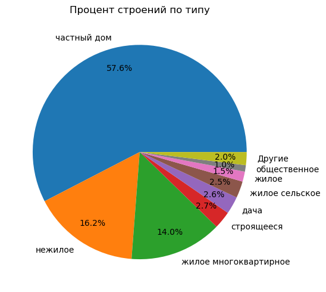

[figure not shown]

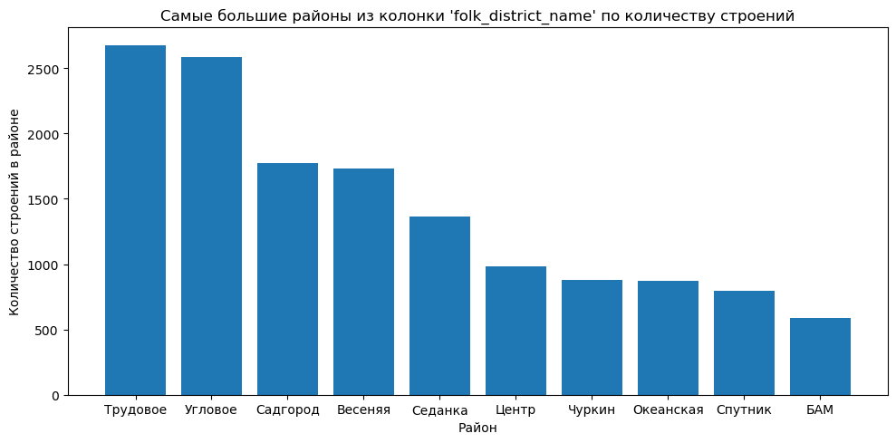

```python
plt.figure(figsize=(10, 5))
buildingTypeCnt = buildingsDf['type'].value_counts()
buildingTypeCnt = pd.concat([buildingTypeCnt.head(8), pd.Series({'Другие': buildingTypeCnt.tail(len(buildingTypeCnt) - 8).sum()})])
plt.pie(buildingTypeCnt.values, labels=buildingTypeCnt.index, autopct='%.1f%%', pctdistance=0.8)
plt.title('Процент строений по типу')
plt.tight_layout()
plt.show()

plt.figure(figsize=(10, 5))
plt.pie(buildingsDf['is_fake'].value_counts().values, labels=['True', 'False'], autopct='%.1f%%')
plt.title("Процент строений по колонке 'is_fake'")
plt.tight_layout()
plt.show()

plt.figure(figsize=(10, 5))
folkDistrCnt = buildingsDf['folk_district_name'].value_counts().head(10)
plt.bar(folkDistrCnt.index, folkDistrCnt.values)
plt.title("Самые большие районы из колонки 'folk_district_name' по количеству строений")
plt.xlabel('Район')
plt.ylabel('Количество строений в районе')
plt.tight_layout()
plt.show()
```

Из графиков видно:

- самые многочисленные строения - частные дома, нежилые и жилые многоквартирные
- около 20% строений указаны неверно
- больше всего строений в районах Трудовое, Угловое и Садгород

Теперь визуализируем характеристики отключений.

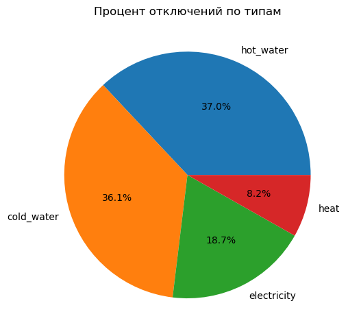

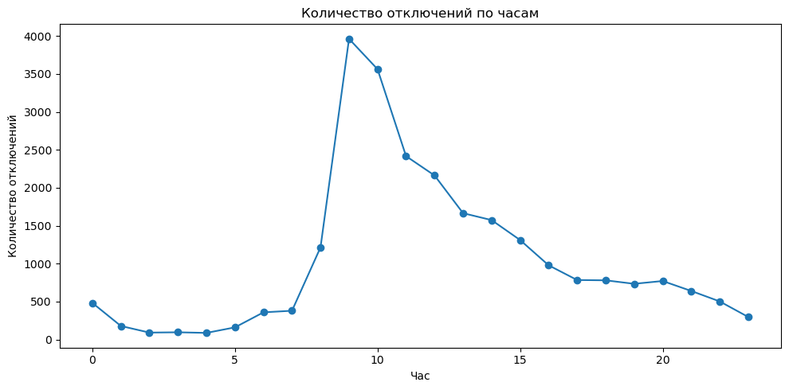

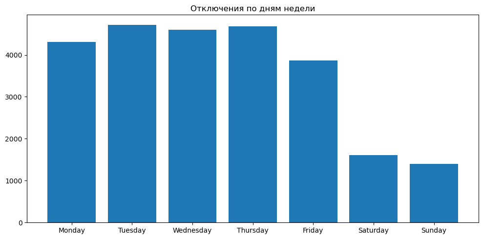

```python
plt.figure(figsize=(10, 5))
blackoutTypeCnt = blackoutsDf['type'].value_counts()
plt.pie(blackoutTypeCnt.values, labels=blackoutTypeCnt.index, autopct='%.1f%%')
plt.title('Процент отключений по типам')
plt.tight_layout()
plt.show()

plt.figure(figsize=(10, 5))
blackoutsPerHour = blackoutsDf['start_date'].dt.hour.value_counts().sort_index()
plt.plot(blackoutsPerHour.index, blackoutsPerHour.values, marker='o')
plt.title('Количество отключений по часам')
plt.xlabel('Час')
plt.ylabel('Количество отключений')
plt.tight_layout()
plt.show()

plt.figure(figsize=(10, 5))
blackoutsPerDay = blackoutsDf['start_date'].dt.day_name().value_counts()
blackoutsPerDay = blackoutsPerDay.reindex(['Monday', 'Tuesday', 'Wednesday', 'Thursday', 'Friday', 'Saturday', 'Sunday'])
plt.bar(blackoutsPerDay.index, blackoutsPerDay.values)
plt.title('Отключения по дням недели')

plt.tight_layout()
plt.show()
```

Из этих графиков видно, что:

- чаще всего отключают горячую и холодную воду, потом электричество и последнее - отопление
- чаще всего отключения происходят в 9-10 часов утра
- меньше всего отключений приходится на субботу и воскресенье

Теперь посмотрим, как еще можно показать полученную информацию с помощью библиотеки seaborn.

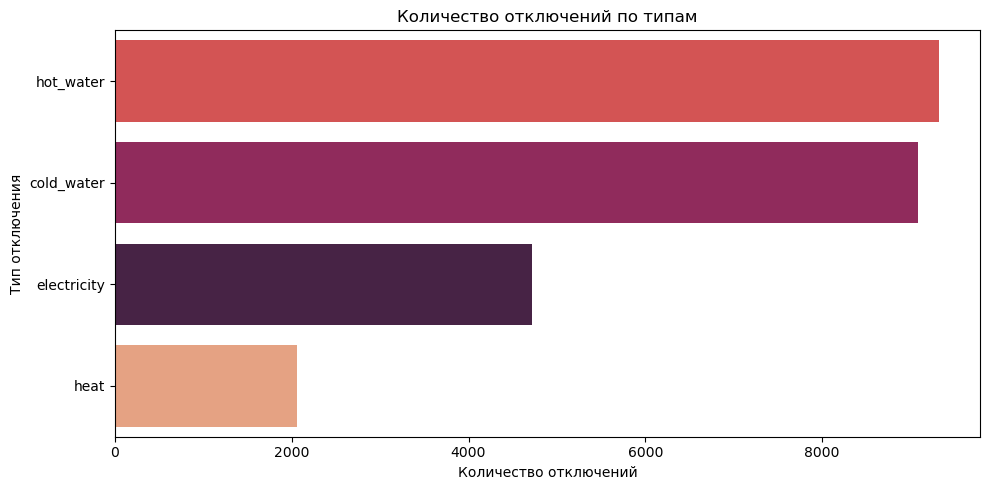

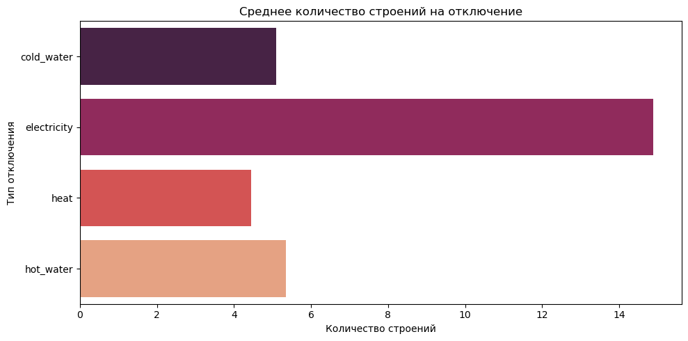

```python
plt.figure(figsize=(10, 5))
sea.countplot(data=blackoutsDf, y='type', order=blackoutsDf['type'].value_counts().index, palette='rocket', hue='type')
plt.title('Количество отключений по типам')
plt.xlabel('Количество отключений')
plt.ylabel('Тип отключения')
plt.tight_layout()
plt.show()

plt.figure(figsize=(10, 5))
buildingTypeMean = blackoutsDf.groupby('type')['building_count'].mean()
sea.barplot(x=buildingTypeMean.values, y=buildingTypeMean.index, palette='rocket', hue=buildingTypeMean.index)
plt.title('Среднее количество строений на отключение')
plt.xlabel('Количество строений')
plt.ylabel('Тип отключения')
plt.tight_layout()
plt.show()
```

На первом графике представлена уже известная нам информация об объеме отключений по типу, но представленная сверху вниз. На втором графике уже новая информация, из которой можно сделать вывод, что отключения электричества в среднем глобальнее и распространяются на большее количество строений.

Теперь посмотрим, как зависит количество отключений от месяца.

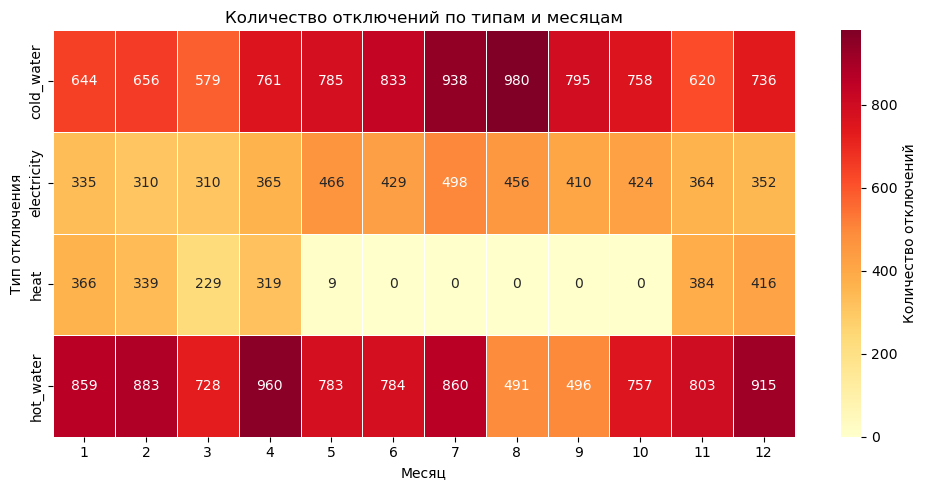

```python
blackoutsDf['month'] = blackoutsDf['start_date'].dt.month
pivot = blackoutsDf.pivot_table(index='type', columns='month', values='id', aggfunc='count', fill_value=0)
plt.figure(figsize=(10, 5))
sea.heatmap(pivot, annot=True, fmt='d', cmap='YlOrRd', linewidths=0.5, cbar_kws={'label': 'Количество отключений'})
plt.title('Количество отключений по типам и месяцам')
plt.xlabel('Месяц')
plt.ylabel('Тип отключения')
plt.tight_layout()
plt.show()
```

Построим еще пару графиков, которые я придумал, смотря на датасет.

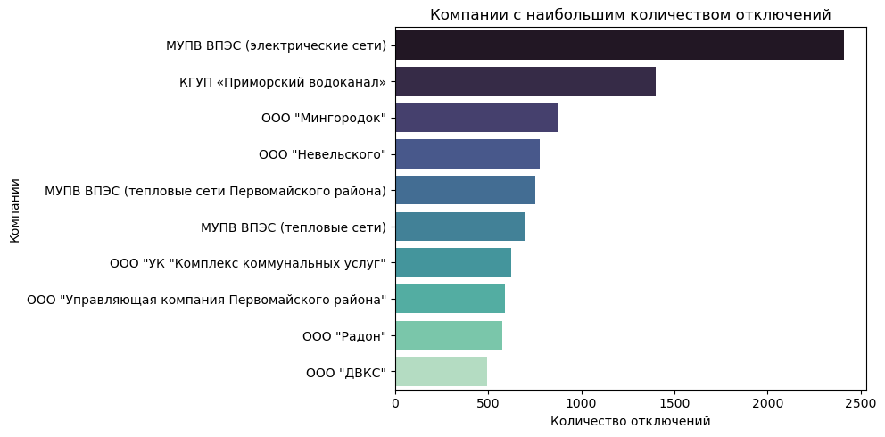

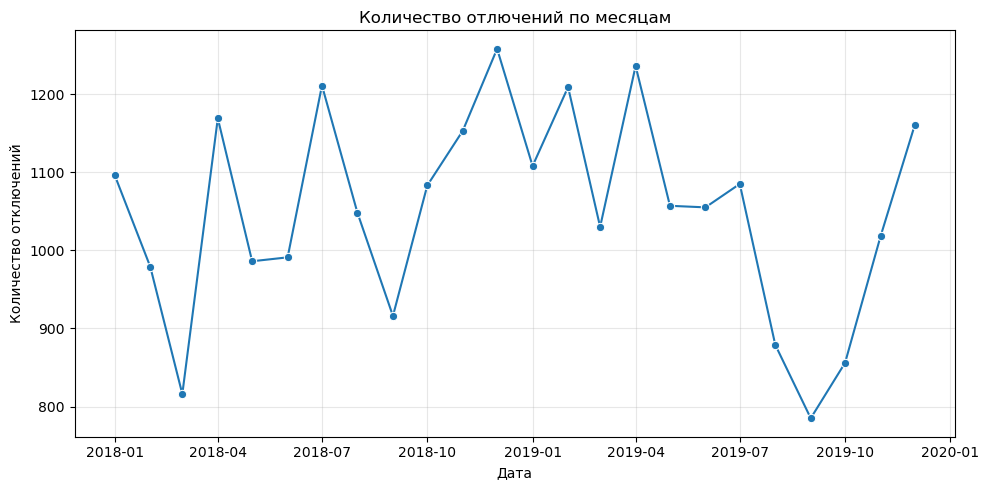

```python
initiatorsMax = blackoutsDf['initiator_name'].value_counts().head(10)
plt.figure(figsize=(10, 5))
sea.barplot(x=initiatorsMax.values, y=initiatorsMax.index, palette='mako', hue=initiatorsMax.index)
plt.title('Компании с наибольшим количеством отключений')
plt.xlabel('Количество отключений')
plt.ylabel('Компании')
plt.tight_layout()
plt.show()

plt.figure(figsize=(10, 5))
sea.lineplot(data=blackoutsDf.set_index('start_date').resample('MS').size(), marker='o')
plt.title('Количество отлючений по месяцам')
plt.xlabel('Дата')
plt.ylabel('Количество отключений')
plt.grid(True, alpha=0.3)
plt.tight_layout()
plt.show()
```

На первом графике видно, что больше всего отключений у МУПВ ВПЭС (электрические сети). На втором выделяющихся закономерностей нет, но можно сказать, что меньше всего отключений за два года было в марте 2018 и в сентябре 2019 года.

## Сложный уровень — Инсайты и функциональные предложения

Реализуем демонстрационный прототип фичи "Календарь планируемых отключений". Импортируем нужные функции и возьмем выборку из таблицы с отключениями за март 2018 года.

```python
from datetime import datetime, timedelta
from matplotlib.patches import Rectangle

blackoutsDfForCalendar = blackoutsDf[(blackoutsDf['start_date'] >= '2018-03-01') & (blackoutsDf['start_date'] <= '2018-03-31')]
blackoutsDfForCalendar = blackoutsDfForCalendar[['start_date', 'end_date', 'type', 'building_count']]
year, month = 2018, 3
```

Напишем функцию показа календаря.

```python
def draw_calendar(selectedDate=None):
    plt.figure(figsize=(15, 10))
    # Разделяем на два subplot: календарь и детали
    temp = plt.GridSpec(2, 1, height_ratios=[2, 1], hspace=0.3)
    calendarSubplot = plt.subplot(temp[0])
    detailsSubplot = plt.subplot(temp[1])

    firstDay = datetime(year, month, 1)
    startDay = (firstDay.weekday()) % 7
    totalDays = (datetime(year, month + 1, 1) - timedelta(days=1) - firstDay).days + 1
    weeks = (totalDays + startDay + 6) // 7

    calendarSubplot.set_title(f'КАЛЕНДАРЬ ОТКЛЮЧЕНИЙ - МАРТ 2018', fontsize=16, fontweight='bold', pad=20)

    days = ['Пн', 'Вт', 'Ср', 'Чт', 'Пт', 'Сб', 'Вс']
    for i in range(7):
        calendarSubplot.text(i + 0.5, weeks + 0.7, days[i], ha='center', va='center',
                             fontweight='bold', fontsize=12, color='#2c3e50')

    colors = {'hot_water': '#4ECDC4', 'cold_water': '#45B7D1', 'electricity': '#FF6B6B', 'heat': '#FFA07A'}
    dayCnt = 0
    for week in range(weeks):
        for day in range(7):
            if (week == 0 and day < startDay) or dayCnt >= totalDays:
                continue

            currentDate = firstDay + timedelta(days=dayCnt)
            outagesOfDay = blackoutsDfForCalendar[blackoutsDfForCalendar['start_date'].dt.date == currentDate.date()]
            dayColor = '#f8f9fa'
            if selectedDate and currentDate.date() == selectedDate.date():
                dayColor = '#fff3cd'

            calendarSubplot.add_patch(Rectangle((day, weeks - week - 1), 1, 1, facecolor=dayColor, edgecolor='#dee2e6', linewidth=1))
            calendarSubplot.text(day + 0.5, weeks - week - 0.3, str(currentDate.day), ha='center', va='center',
                                 fontsize=11, fontweight='bold' if currentDate.date() == datetime.now().date() else 'normal')

            if not outagesOfDay.empty:
                outageTypes = outagesOfDay['type'].unique()
                markY = weeks - week - 0.7
                for i, outageType in enumerate(outageTypes[:4]):
                    markX = day + 0.2 + i * 0.15
                    calendarSubplot.plot(markX, markY, 's', markersize=8,
                                         color=colors[outageType], markeredgecolor='white', markeredgewidth=0.5)
                if len(outageTypes) > 4:
                    calendarSubplot.text(day + 0.9, markY, f"+{len(outageTypes)-4}",
                                         fontsize=8, ha='right', va='center', color='#6c757d')
            dayCnt += 1

    calendarSubplot.set_xlim(0, 7)
    calendarSubplot.set_ylim(0, weeks + 1)
    calendarSubplot.set_aspect('equal')
    calendarSubplot.axis('off')

    if selectedDate:
        outagesOfDay = blackoutsDfForCalendar[blackoutsDfForCalendar['start_date'].dt.date == selectedDate.date()]
        if not outagesOfDay.empty:
            detailsSubplot.text(0, 5.5, f'ОТКЛЮЧЕНИЯ НА {selectedDate.strftime("%d.%m.%Y")}', fontsize=14, fontweight='bold', color='#dc3545')

            yPosition = 5.0
            for outageType in outagesOfDay['type'].unique():
                typeOutages = outagesOfDay[outagesOfDay['type'] == outageType]
                detailsSubplot.text(0.2, yPosition, f'{outageType.upper()} ({len(typeOutages)} откл.):',
                                    fontsize=11, fontweight='bold', color=colors[outageType])
                yPosition -= 0.3

                for _, outage in typeOutages.iterrows():
                    detailsSubplot.text(0.5, yPosition, f"   {outage['start_date']}-{outage['end_date']} | {outage['building_count']} адресов",
                                        fontsize=10)
                    yPosition -= 0.25
                yPosition -= 0.1

            detailsSubplot.text(0, yPosition - 0.3,
                                f"ИТОГО: {len(outagesOfDay)} отключений, затронуто {outagesOfDay['building_count'].sum()} адресов",
                                fontsize=11, fontweight='bold', style='italic')
        else:
            detailsSubplot.text(5, 3, f'{selectedDate.strftime("%d.%m.%Y")} - отключений не запланировано',
                                ha='center', fontsize=12, style='italic', color='#28a745')
    else:
        detailsSubplot.text(5, 3, 'Выберите дату в календаре для просмотра деталей', ha='center', fontsize=12, style='italic', color='#6c757d')

    detailsSubplot.set_xlim(0, 10)
    detailsSubplot.set_ylim(0, 6)
    detailsSubplot.axis('off')

    plt.show()
```

Посмотрим на получившийся прототип календаря.

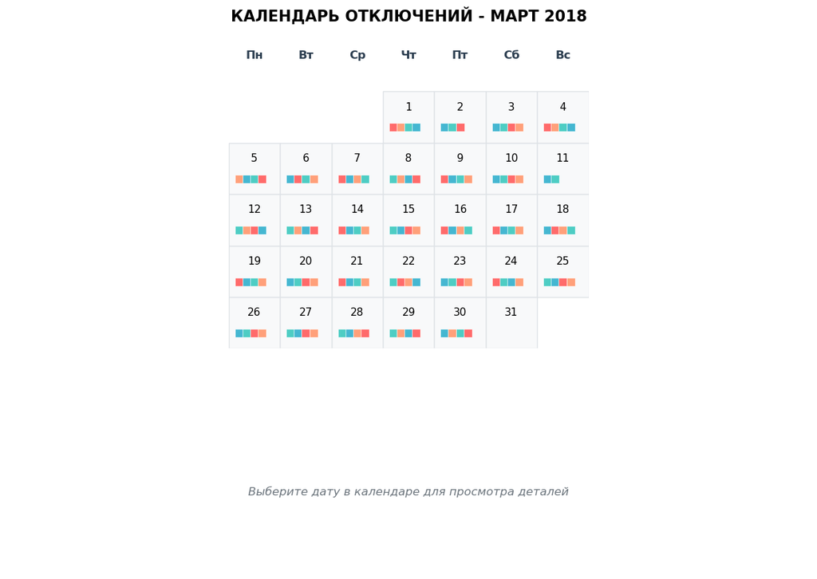

```python
draw_calendar()
```

Посмотрим на прототип календаря с нажатой датой.

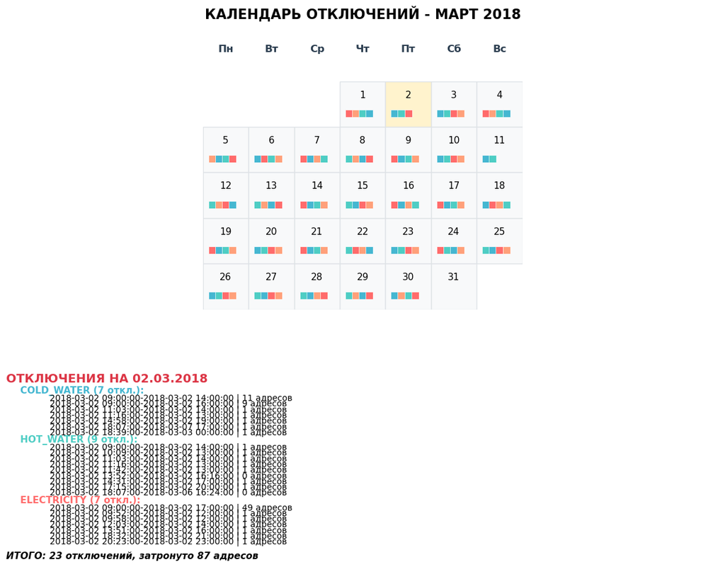

```python
draw_calendar(datetime(2018, 3, 2))
```

На демонстрационном прототипе видно, как примерно будет выглядеть интерактивный календарь.